# Многокритериальная оптимизация

### Метод идеальной точки

Метод идеальной точки (Метод Салуквадзе) состоит из двух этапов. На первом этапе находим наилучшее значение по всем критериям.

```r
(u1<-max(d$u1))
```

```
## [1] 40
```

```r
(u2<-min(d$u2))
```

```
## [1] 0
```

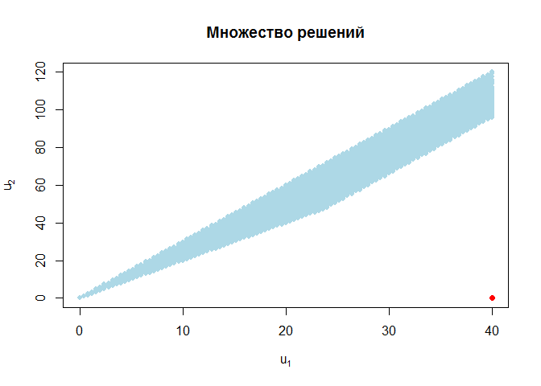

```r
plot(d$u2~d$u1,type="p",pch=19,col="lightblue",main="Множество решений",xlab=expression(u[1]),ylab=expression(u[2]),cex=0.8)
points(u1,u2,pch=19,col="red")
```

Данная точка u<sup>0</sup> не принадлежит области допустимых решений. На втором этапе найдем решение, как точку, ближайшую к данной:

$R(u(x),{u^0}) \to \min ,\;x \in X$

где R– расстояние от u(X) до u<sup>0</sup>. В качестве R можно выбрать функцию:

${\left( {\sum\limits_{i = 1}^M {{{(u_i^0 - {u_i}(x))}^l}} } \right)^{\frac{1}{l}}}$

Произведем необходимые расчеты:

```r
d.new<-d
l<-2
d.new$s<-((u1-d.new$u1)^l+(u2-d.new$u2)^l)^(1/l)
(u.opt<-d.new[which.min( d.new$s),])
```

```
##    x1 x2 u1 u2        s
## 21  2  0  8 16 35.77709
```

Построим график

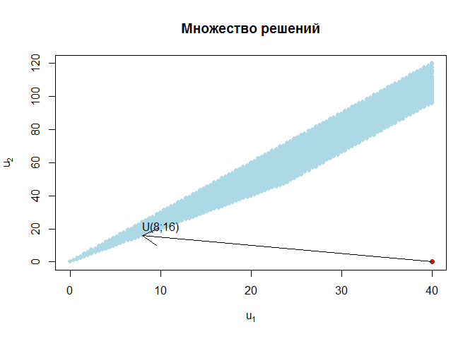

```r
plot(d$u2~d$u1,type="p",pch=19,col="lightblue",main="Множество решений",xlab=expression(u[1]),ylab=expression(u[2]),cex=0.8)
points(u1,u2,pch=19,col="red")
arrows(u1,u2,u.opt$u1,u.opt$u2)
text(u.opt$u1+2,u.opt$u2+5,paste0("U(",u.opt$u1,";",u.opt$u2,")"))
```

### Метод лексико-графического упорядочивания

На основании опроса ЛПР критерии ранжируются по важности. Предположим, что первым критерием мы выбираем охват аудитории. Тогда имеем множество возможных решений при максимальном критерии u<sub>1</sub>

```r
(z<-max(d$u1))
```

```
## [1] 40
```

```r
head(d.new<-subset(d,u1==z))
```

```
##       x1  x2 u1    u2
## 1281 6.0 2.0 40  96.0
## 1340 5.8 2.1 40  96.8
## 1399 5.6 2.2 40  97.6
## 1458 5.4 2.3 40  98.4
## 1517 5.2 2.4 40  99.2
## 1576 5.0 2.5 40 100.0
```

Находим наилучшее значение по второму критерию:

```r
(u.opt<-d.new[which.min( d.new$u2),])
```

```
##      x1 x2 u1 u2
## 1281  6  2 40 96
```

Представим графически:

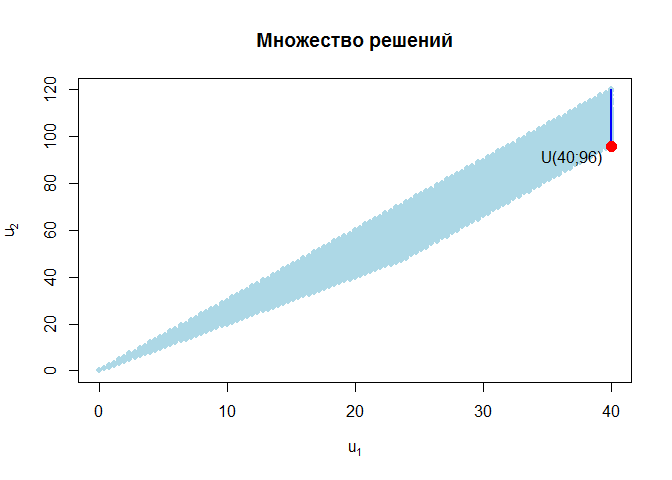

```r
plot(d$u2~d$u1,type="p",pch=19,col="lightblue",main="Множество решений",xlab=expression(u[1]),ylab=expression(u[2]),cex=0.8)
lines(d.new$u1,d.new$u2,col="blue",lwd=2)
points(u.opt$u1,u.opt$u2,pch=19,col="red",cex=1.5)
text(u.opt$u1-3,u.opt$u2-5,paste0("U(",u.opt$u1,";",u.opt$u2,")"))
```

### Метод линейной свертки

ЛПР задает значение весов критериев и решается задача максимизации критерия. Поскольку предполагается, что оба критерия должны быть максимизируемы, критерий u<sub>2</sub> возьмем со знакоми минус. Пусть веса критериев равны 0.8 и 0.2, тогда:

```r
d.new<-d
d.new$s<-d.new$u1*0.8-d.new$u2*0.2
head(d.new)
```

```
##    x1 x2  u1  u2    s
## 1 0.0  0 0.0 0.0 0.00
## 2 0.1  0 0.4 0.8 0.16
## 3 0.2  0 0.8 1.6 0.32
## 4 0.3  0 1.2 2.4 0.48
## 5 0.4  0 1.6 3.2 0.64
## 6 0.5  0 2.0 4.0 0.80
```

```r
tail(d.new)
```

```
##       x1  x2   u1    u2    s
## 2931 0.2 4.8 39.2 116.8 8.00
## 2932 0.3 4.8 39.6 117.6 8.16
## 2990 0.0 4.9 39.2 117.6 7.84
## 2991 0.1 4.9 39.6 118.4 8.00
## 2992 0.2 4.9 40.0 119.2 8.16
## 3051 0.0 5.0 40.0 120.0 8.00
```

```r
subset(d.new,s==max(d.new$s))
```

```
##      x1 x2 u1 u2    s
## 1281  6  2 40 96 12.8
```

```r
d.new<-d
d.new$s<-d.new$u1*0.5-d.new$u2*0.5
head(d.new)
```

```
##    x1 x2  u1  u2    s
## 1 0.0  0 0.0 0.0  0.0
## 2 0.1  0 0.4 0.8 -0.2
## 3 0.2  0 0.8 1.6 -0.4
## 4 0.3  0 1.2 2.4 -0.6
## 5 0.4  0 1.6 3.2 -0.8
## 6 0.5  0 2.0 4.0 -1.0
```

```r
tail(d.new)
```

```
##       x1  x2   u1    u2     s
## 2931 0.2 4.8 39.2 116.8 -38.8
## 2932 0.3 4.8 39.6 117.6 -39.0
## 2990 0.0 4.9 39.2 117.6 -39.2
## 2991 0.1 4.9 39.6 118.4 -39.4
## 2992 0.2 4.9 40.0 119.2 -39.6
## 3051 0.0 5.0 40.0 120.0 -40.0
```

```r
subset(d.new,s==max(d.new$s))
```

```
##   x1 x2 u1 u2 s
## 1  0  0  0  0 0
```

Нетрудно увидеть, что фактически в данном случае мы сводим задачу к задаче линейного программирования. Пусть k<sub>1</sub> и k<sub>2</sub> весовые коэффициенты, тогда имеем.

${k_1}{u_1}-{k_2}{u_2}\to \max$

Откуда:

${k_1}(4{x_1} + 8{x_2})-{k_2}(8{x_1} + 24{x_2})=(4 k_1-8 k_2 )x_1+(8 k_1 - 24 K_2) x_2 \to \max$

при тех же ограничениях

$\left\{ {\begin{array} {{x_1} \le 6}\\ {{x_1} + 2{x_2} \le 10}\\ {{x_1} \ge 0;\;{x_2} \ge 0} \end{array}} \right.$

Пусть k<sub>1</sub>=0.8, а k<sub>2</sub>=0.2

```r
k1<-0.8
k2<-0.2
f.obj <- c(4*k1-8*k2, 8*k1-24*k2) # Описали целевую функцию
names(f.obj) <-c("X1","X2")
a.mat<-rbind(c(1,0), # матрица
             c(1,2),   # коээфициентов
             c(1,0),    # при ограничениях
             c(0,1))
a.dir<-c("<=","<=",">=",">=")
b.vec<-c(6,10,0,0) # вектор ограничений
(result<-lp ("max", f.obj, a.mat, a.dir, b.vec))
```

```
## Success: the objective function is 12.8
```

```r
result$solution
```

```
## [1] 6 2
```

Результаты аналогичны вышеприведенному примеру.